# Decision Tree using Titanic Dataset (CARET package)

Himansu Sahoo

December 29, 2015

This is the example showing how to use decision tree algorithm in titanic dataset to predict survival rate of passengers.

link to kaggle competition : https://www.kaggle.com/c/titanic

### Step 1 : Getting the Data into R

```r
train_raw <- read.csv(file="../datasets/titanic-train.csv", na.strings=c(""," ", "NA", "NAN"))
test_raw <- read.csv(file="../datasets/titanic-test.csv", na.strings=c(""," ", "NA", "NAN"))
# stringsAsFactors=TRUE by default
# treat all empty values, NAN as NA's
```

```r
library(dplyr)
# convert into dplyr tbl format
train_raw <- tbl_df(train_raw)
test_raw <- tbl_df(test_raw)
```

#### Check the training dataset

```r
dim(train_raw)
```

```
## [1] 891  12
```

```r
# the dataset contains 891 rows/observations and 12 variables
#nrow(train_raw); ncol(train_raw)
#head(train_raw) # print first 6 rows
#tail(train_raw) # print last 6 rows
#str(train_raw) # will show class of each variable
# 'data.frame':    891 obs. of  12 variables:
#summary(train_raw)
glimpse(train_raw) # same as str() in base R
```

```
## Observations: 891
## Variables: 12
## $ PassengerId (int) 1, 2, 3, 4, 5, 6, 7, 8, 9, 10, 11, 12, 13, 14, 15,...
## $ Survived    (int) 0, 1, 1, 1, 0, 0, 0, 0, 1, 1, 1, 1, 0, 0, 0, 1, 0,...
## $ Pclass      (int) 3, 1, 3, 1, 3, 3, 1, 3, 3, 2, 3, 1, 3, 3, 3, 2, 3,...
## $ Name        (fctr) Braund, Mr. Owen Harris, Cumings, Mrs. John Bradl...
## $ Sex         (fctr) male, female, female, female, male, male, male, m...
## $ Age         (dbl) 22, 38, 26, 35, 35, NA, 54, 2, 27, 14, 4, 58, 20, ...
## $ SibSp       (int) 1, 1, 0, 1, 0, 0, 0, 3, 0, 1, 1, 0, 0, 1, 0, 0, 4,...
## $ Parch       (int) 0, 0, 0, 0, 0, 0, 0, 1, 2, 0, 1, 0, 0, 5, 0, 0, 1,...
## $ Ticket      (fctr) A/5 21171, PC 17599, STON/O2. 3101282, 113803, 37...
## $ Fare        (dbl) 7.2500, 71.2833, 7.9250, 53.1000, 8.0500, 8.4583, ...
## $ Cabin       (fctr) NA, C85, NA, C123, NA, NA, E46, NA, NA, NA, G6, C...
## $ Embarked    (fctr) S, C, S, S, S, Q, S, S, S, C, S, S, S, S, S, S, Q...
```

Looking at `str(train_raw)`  
Name : Factor w/ 891 levels  
Ticket : Factor w/ 681 levels  
Cabin : Factor w/ 147 levels

Note that Name and ticket are strings, they are read as factors.  
Looking at `summary(train_raw)`, Age has 177 NA’s, Cabin has 687 NA’s, Embarked has 2 NA’s.

#### Check the testing dataset

```r
dim(test_raw)
```

```
## [1] 418  11
```

```r
#str(test_raw)
#'data.frame':    418 obs. of  11 variables:
#summary(test_raw)
glimpse(test_raw)
```

```
## Observations: 418
## Variables: 11
## $ PassengerId (int) 892, 893, 894, 895, 896, 897, 898, 899, 900, 901, ...
## $ Pclass      (int) 3, 3, 2, 3, 3, 3, 3, 2, 3, 3, 3, 1, 1, 2, 1, 2, 2,...
## $ Name        (fctr) Kelly, Mr. James, Wilkes, Mrs. James (Ellen Needs...
## $ Sex         (fctr) male, female, male, male, female, male, female, m...
## $ Age         (dbl) 34.5, 47.0, 62.0, 27.0, 22.0, 14.0, 30.0, 26.0, 18...
## $ SibSp       (int) 0, 1, 0, 0, 1, 0, 0, 1, 0, 2, 0, 0, 1, 1, 1, 1, 0,...
## $ Parch       (int) 0, 0, 0, 0, 1, 0, 0, 1, 0, 0, 0, 0, 0, 0, 0, 0, 0,...
## $ Ticket      (fctr) 330911, 363272, 240276, 315154, 3101298, 7538, 33...
## $ Fare        (dbl) 7.8292, 7.0000, 9.6875, 8.6625, 12.2875, 9.2250, 7...
## $ Cabin       (fctr) NA, NA, NA, NA, NA, NA, NA, NA, NA, NA, NA, NA, B...
## $ Embarked    (fctr) Q, S, Q, S, S, S, Q, S, C, S, S, S, S, S, S, C, Q...
```

Looking at `str(test_raw)`  
Name : Factor w/ 418 levels  
Ticket : Factor w/ 363 levels  
Cabin : Factor w/ 76 levels

Looking at *summary(test_raw)*, Fare has 1 NA, Cabin has 327 NA’s.

#### Removing Variables

passengerId, Name are an unique identifier, remove this from the modeling remove Ticket, Cabin

```r
train_final <- train_raw %>% select(-c(PassengerId, Name, Ticket, Cabin))
test_final <- test_raw
```

#### Missing Value treatment

```r
colSums(is.na(train_final))
```

```
## Survived   Pclass      Sex      Age    SibSp    Parch     Fare Embarked
##        0        0        0      177        0        0        0        2
```

```r
train_final$Age[is.na(train_final$Age)] <- median(train_final$Age, na.rm=TRUE)

summary(train_final$Embarked)
```

```
##    C    Q    S NA's
##  168   77  644    2
```

```r
#table() willn't print NA's
# maximum observations have S, replace NA's by S
train_final$Embarked[is.na(train_final$Embarked)] <- "S"
colSums(is.na(train_final))
```

```
## Survived   Pclass      Sex      Age    SibSp    Parch     Fare Embarked
##        0        0        0        0        0        0        0        0
```

Change the response variable to a factor variable, otherwise CART train function will give problem. It is thinking the problem as regression and outcome has only two levels. Also, change the level names of the response variable, otherwise will give problem when calculating class probabilites.

```r
train_final$Survived <- as.factor(train_final$Survived)
#class(train_final$Survived) # factor
str(train_final$Survived) # Factor w/ 2 levels "0","1":
```

```
##  Factor w/ 2 levels "0","1": 1 2 2 2 1 1 1 1 2 2 ...
```

```r
#levels(train_final$Survived)[levels(train_final$Survived)=="0"] <- "No"
#levels(train_final$Survived)[levels(train_final$Survived)=="1"] <- "Yes"
#levels(train_final$Survived)
```

#### Splitting data into training and validation set

We will use the `createDataPartition` function in `caret` package to split the `train_data` into 70% train_set and valid_set. Set seed in the beginning to reproduce the same result in future.

```r
library(caret)
set.seed(1099)
inTrain <- createDataPartition(y=train_final$Survived, p=0.70, list=FALSE)
train_set <- train_final[inTrain,]
valid_set <- train_final[-inTrain,]
```

```r
train_per <- (nrow(train_set)/nrow(train_final))*100
test_per <- (nrow(valid_set)/nrow(train_final))*100
cat("******** training dataset is : ", train_per, "% \n")
```

```
## ******** training dataset is :  70.1459 %
```

```r
cat("******** testing dataset is : ", test_per, "% \n")
```

```
## ******** testing dataset is :  29.8541 %
```

### Step 2 : Building a Decision Tree (CART) Model using CARET package

We will use the `caret` package in R to build the **decisionTree** model (CART) with method **rpart**.

```r
library(rpart)
dt_model <- train(Survived~., method="rpart", data=train_set)
```

After running the model, you will get the following Warnings. Make sure to change the target variable to a factor variable.

```
## Warning in train.default(x, y, weights = w, ...): You are trying to do
## regression and your outcome only has two possible values Are you trying to
## do classification? If so, use a 2 level factor as your outcome column.
```

```
## Warning in nominalTrainWorkflow(x = x, y = y, wts = weights, info =
## trainInfo, : There were missing values in resampled performance measures.
```

#### Print different Model functions

```r
class(dt_model) # "train"         "train.formula"
```

```
## [1] "train"         "train.formula"
```

```r
print(dt_model) # str(), summary() will print rubbish
```

```
## CART
##
## 625 samples
##   7 predictor
##   2 classes: '0', '1'
##
## No pre-processing
## Resampling: Bootstrapped (25 reps)
## Summary of sample sizes: 625, 625, 625, 625, 625, 625, ...
## Resampling results across tuning parameters:
##
##   cp          Accuracy   Kappa      Accuracy SD  Kappa SD
##   0.01250000  0.8015914  0.5670174  0.02613620   0.05283086
##   0.03333333  0.7933803  0.5443304  0.02375807   0.04958070
##   0.43750000  0.6754800  0.1886968  0.08569538   0.25835906
##
## Accuracy was used to select the optimal model using  the largest value.
## The final value used for the model was cp = 0.0125.
```

```r
names(dt_model)
```

```
##  [1] "method"       "modelInfo"    "modelType"    "results"
##  [5] "pred"         "bestTune"     "call"         "dots"
##  [9] "metric"       "control"      "finalModel"   "preProcess"
## [13] "trainingData" "resample"     "resampledCM"  "perfNames"
## [17] "maximize"     "yLimits"      "times"        "terms"
## [21] "coefnames"    "contrasts"    "xlevels"
```

```r
ls(dt_model)
```

```
##  [1] "bestTune"     "call"         "coefnames"    "contrasts"
##  [5] "control"      "dots"         "finalModel"   "maximize"
##  [9] "method"       "metric"       "modelInfo"    "modelType"
## [13] "perfNames"    "pred"         "preProcess"   "resample"
## [17] "resampledCM"  "results"      "terms"        "times"
## [21] "trainingData" "xlevels"      "yLimits"
```

```r
dt_model$method
```

```
## [1] "rpart"
```

```r
dt_model$modelType
```

```
## [1] "Classification"
```

```r
dt_model$call
```

```
## train.formula(form = Survived ~ ., data = train_set, method = "rpart")
```

```r
dt_model$metric
```

```
## [1] "Accuracy"
```

```r
dt_model$perfNames
```

```
## [1] "Accuracy" "Kappa"
```

```r
dt_model$bestTune
```

```
##       cp
## 1 0.0125
```

```r
dt_model$coefnames # will print long list
```

```
## [1] "Pclass"    "Sexmale"   "Age"       "SibSp"     "Parch"     "Fare"
## [7] "EmbarkedQ" "EmbarkedS"
```

```r
dt_model$xlevels # will print long list
```

```
## $Sex
## [1] "female" "male"
##
## $Embarked
## [1] "C" "Q" "S"
```

```r
dt_model$results
```

```
##           cp  Accuracy     Kappa AccuracySD    KappaSD
## 1 0.01250000 0.8015914 0.5670174 0.02613620 0.05283086
## 2 0.03333333 0.7933803 0.5443304 0.02375807 0.04958070
## 3 0.43750000 0.6754800 0.1886968 0.08569538 0.25835906
```

```r
dt_model$finalModel # output is rpart
```

```
## n= 625
##
## node), split, n, loss, yval, (yprob)
##       * denotes terminal node
##
##  1) root 625 240 0 (0.61600000 0.38400000)
##    2) Sexmale>=0.5 406  78 0 (0.80788177 0.19211823) *
##    3) Sexmale< 0.5 219  57 1 (0.26027397 0.73972603)
##      6) Pclass>=2.5 103  51 1 (0.49514563 0.50485437)
##       12) Fare>=23.35 20   2 0 (0.90000000 0.10000000) *
##       13) Fare< 23.35 83  33 1 (0.39759036 0.60240964) *
##      7) Pclass< 2.5 116   6 1 (0.05172414 0.94827586) *
```

```r
dt_model$bestTune
```

```
##       cp
## 1 0.0125
```

#### Plotting the decision tree

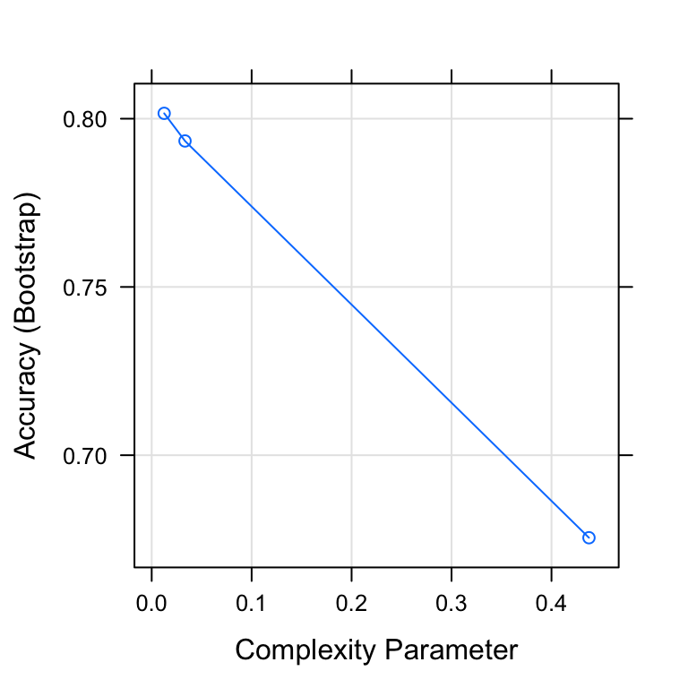

```r
plot(dt_model)
```

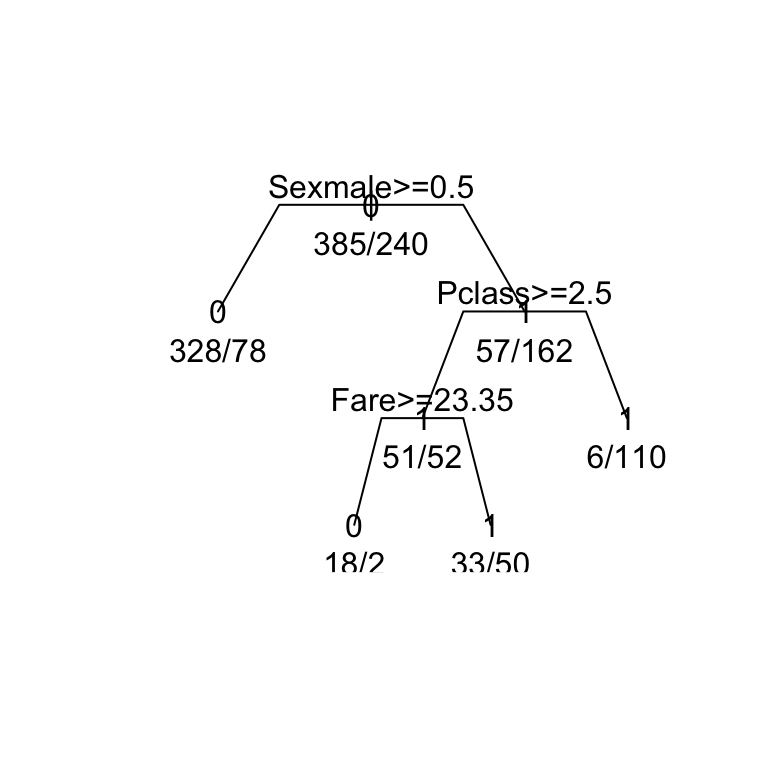

```r
##plot(dt_model$finalModel) # this will just plot an empty tree
plot(dt_model$finalModel, uniform=TRUE, branch=0.6, margin=0.1)
text(dt_model$finalModel, all=TRUE, use.n=TRUE)
```

```r
library(rattle)
```

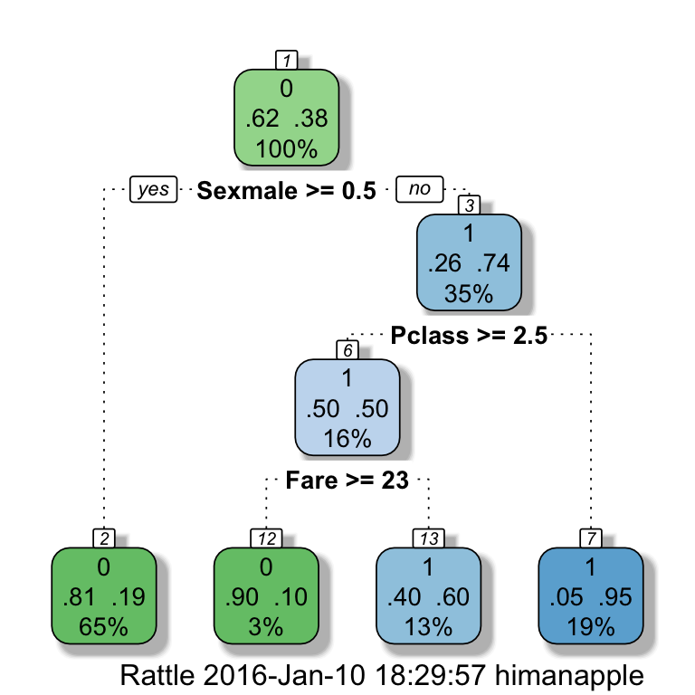

```r
fancyRpartPlot(dt_model$finalModel)
```

#### Variable Importance

```r
var_imp <- varImp(dt_model, scale=FALSE)
# by default varImp returns scaled results in the range 0-100, need to put scale=FALSE
print(var_imp)
```

```
## rpart variable importance
##
##           Overall
## Sexmale    85.322
## Pclass     56.308
## Fare       41.690
## EmbarkedS  16.971
## Age        15.114
## Parch      11.554
## SibSp       9.943
## EmbarkedQ   0.000
```

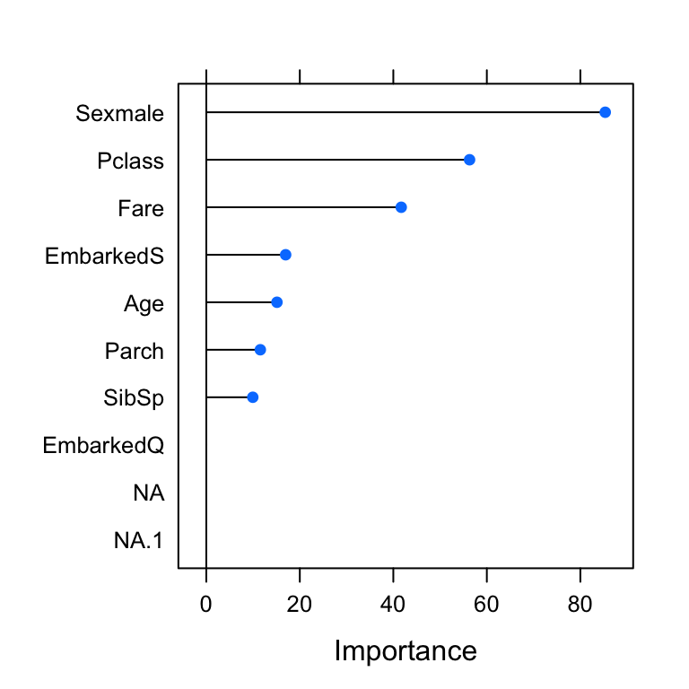

```r
# varImp(dt_model$finalModel) # output is a dataframe

plot(var_imp, top=10)
```

### Step 3 : Model Validation

#### Check the model performance with train_set

```r
#predict(dt_model)
#Error in eval(expr, envir, enclos) : object 'Sexmale' not found

pred_train1 <- predict(dt_model, newdata=train_set)
##pred_train1 <- predict(dt_model, newdata=train_set, type="raw") # same as above, default is "raw" for train object
#print(class(pred_train1)) # this is a factor variable
print(confusionMatrix(pred_train1, train_set$Survived))
```

```
## Confusion Matrix and Statistics
##
##           Reference
## Prediction   0   1
##          0 346  80
##          1  39 160
##
##                Accuracy : 0.8096
##                  95% CI : (0.7766, 0.8397)
##     No Information Rate : 0.616
##     P-Value [Acc > NIR] : < 2.2e-16
##
##                   Kappa : 0.5842
##  Mcnemar's Test P-Value : 0.0002456
##
##             Sensitivity : 0.8987
##             Specificity : 0.6667
##          Pos Pred Value : 0.8122
##          Neg Pred Value : 0.8040
##              Prevalence : 0.6160
##          Detection Rate : 0.5536
##    Detection Prevalence : 0.6816
##       Balanced Accuracy : 0.7827
##
##        'Positive' Class : 0
##
```

```r
## Accuracy : 0.8096

pred_train2_prob <- predict(dt_model$finalModel) # output is a matrix, it will output probability
#pred_train2_prob <- predict(dt_model$finalModel, type="prob") # same as above, default is prob for rpart object
print(head(pred_train2_prob))
```

```
##               0         1
## [1,] 0.80788177 0.1921182
## [2,] 0.05172414 0.9482759
## [3,] 0.05172414 0.9482759
## [4,] 0.80788177 0.1921182
## [5,] 0.05172414 0.9482759
## [6,] 0.39759036 0.6024096
```

```r
# the deafult is to give probability, to get class of each observation, use type="class"
pred_train2_class <- predict(dt_model$finalModel, type="class")
print(confusionMatrix(pred_train2_class, train_set$Survived))
```

```
## Confusion Matrix and Statistics
##
##           Reference
## Prediction   0   1
##          0 346  80
##          1  39 160
##
##                Accuracy : 0.8096
##                  95% CI : (0.7766, 0.8397)
##     No Information Rate : 0.616
##     P-Value [Acc > NIR] : < 2.2e-16
##
##                   Kappa : 0.5842
##  Mcnemar's Test P-Value : 0.0002456
##
##             Sensitivity : 0.8987
##             Specificity : 0.6667
##          Pos Pred Value : 0.8122
##          Neg Pred Value : 0.8040
##              Prevalence : 0.6160
##          Detection Rate : 0.5536
##    Detection Prevalence : 0.6816
##       Balanced Accuracy : 0.7827
##
##        'Positive' Class : 0
##
```

```r
## Accuracy : 0.8096

# if you will apply to a newdata, gives problem
#predict(dt_model$finalModel, newdata=train_set)
#Error in eval(expr, envir, enclos) : object 'Sexmale' not found

# in caret train type is either raw or prob
table(valid_set$Survived)
```

```
##
##   0   1
## 164 102
```

```r
pred_valid <- predict(dt_model, newdata=valid_set) # output is a factor variable
###pred_valid <- predict(dt_model, newdata=valid_set, type="raw") # same as above, default is raw for train object
table(pred_valid)
```

```
## pred_valid
##   0   1
## 178  88
```

```r
print(confusionMatrix(pred_valid, valid_set$Survived))
```

```
## Confusion Matrix and Statistics
##
##           Reference
## Prediction   0   1
##          0 146  32
##          1  18  70
##
##                Accuracy : 0.812
##                  95% CI : (0.7598, 0.8571)
##     No Information Rate : 0.6165
##     P-Value [Acc > NIR] : 4.357e-12
##
##                   Kappa : 0.5919
##  Mcnemar's Test P-Value : 0.06599
##
##             Sensitivity : 0.8902
##             Specificity : 0.6863
##          Pos Pred Value : 0.8202
##          Neg Pred Value : 0.7955
##              Prevalence : 0.6165
##          Detection Rate : 0.5489
##    Detection Prevalence : 0.6692
##       Balanced Accuracy : 0.7883
##
##        'Positive' Class : 0
##
```

```r
## Accuracy : 0.812

#Error in predict.train(dt_model, newdata = valid_set, type = "class") :
#  type must be either "raw" or "prob"
```

```
# for train object, default value of type="raw" gives factor variable
# if you will give type="prob" will give problem:
# Error in .data.frame(out, , obsLevels, drop = FALSE) :
#  undefined columns selected
# you will encounter this while calculating ROC curve
```

#### Check the model performance with valid_set

Do the missing value treatment, otherwise confusionMatrix will give this message.

```
Error in table(data, reference, dnn = dnn, ...) :
  all arguments must have the same length
```

```r
table(valid_set$Survived)
```

```
##
##   0   1
## 164 102
```

```r
pred_valid <- predict(dt_model, newdata=valid_set)
table(pred_valid)
```

```
## pred_valid
##   0   1
## 178  88
```

```r
confusionMatrix(pred_valid, valid_set$Survived)
```

```
## Confusion Matrix and Statistics
##
##           Reference
## Prediction   0   1
##          0 146  32
##          1  18  70
##
##                Accuracy : 0.812
##                  95% CI : (0.7598, 0.8571)
##     No Information Rate : 0.6165
##     P-Value [Acc > NIR] : 4.357e-12
##
##                   Kappa : 0.5919
##  Mcnemar's Test P-Value : 0.06599
##
##             Sensitivity : 0.8902
##             Specificity : 0.6863
##          Pos Pred Value : 0.8202
##          Neg Pred Value : 0.7955
##              Prevalence : 0.6165
##          Detection Rate : 0.5489
##    Detection Prevalence : 0.6692
##       Balanced Accuracy : 0.7883
##
##        'Positive' Class : 0
##
```

```r
## Accuracy : 0.812
```

### Step 4 : Calculate ROC Curve using ROCR package

In order to plot ROC curve, we need to calculate probabilities for each level of the response variable.

```
When you ask for class probabilities, model predictions are a data frame with separate columns for each class/level. If the response variable doesn't have levels that are valid column names, data.frame converts then to valid names. That creates a problem because the code is looking for a specific name but the data frame as a different (but valid) name.
```

0 and 1 are not valid R variable names, we get errors when generating class probabilities. change them to “NO” and “Yes”

```
Error in `[.data.frame`(out, , obsLevels, drop = FALSE) :
  undefined columns selected
```

```r
levels(train_set$Survived)[levels(train_set$Survived)=="0"] <- "No"
levels(train_set$Survived)[levels(train_set$Survived)=="1"] <- "Yes"
levels(train_set$Survived)
```

```
## [1] "No"  "Yes"
```

```r
levels(valid_set$Survived)[levels(valid_set$Survived)=="0"] <- "No"
levels(valid_set$Survived)[levels(valid_set$Survived)=="1"] <- "Yes"
levels(valid_set$Survived)
```

```
## [1] "No"  "Yes"
```

```r
dt_model_prob <- train(Survived~., data=train_set, method="rpart")

library(ROCR)
```

```r
# Calculate ROC Curve using ROCR package
pred_valid_prob <- predict(dt_model_prob, newdata=valid_set, type="prob")
# this will output probabaility
roc_pred <- prediction(pred_valid_prob[, 2], valid_set$Survived)
roc_perf <- performance(roc_pred, measure="tpr", x.measure="fpr")

roc_auc <- performance(roc_pred, measure="auc", x.measure="cutoff")
auc <- unlist(roc_auc@y.values)
cat("*********** Value of AUC : ", auc, "\n") # AUC :  0.8107963
```

```
## *********** Value of AUC :  0.8107963
```

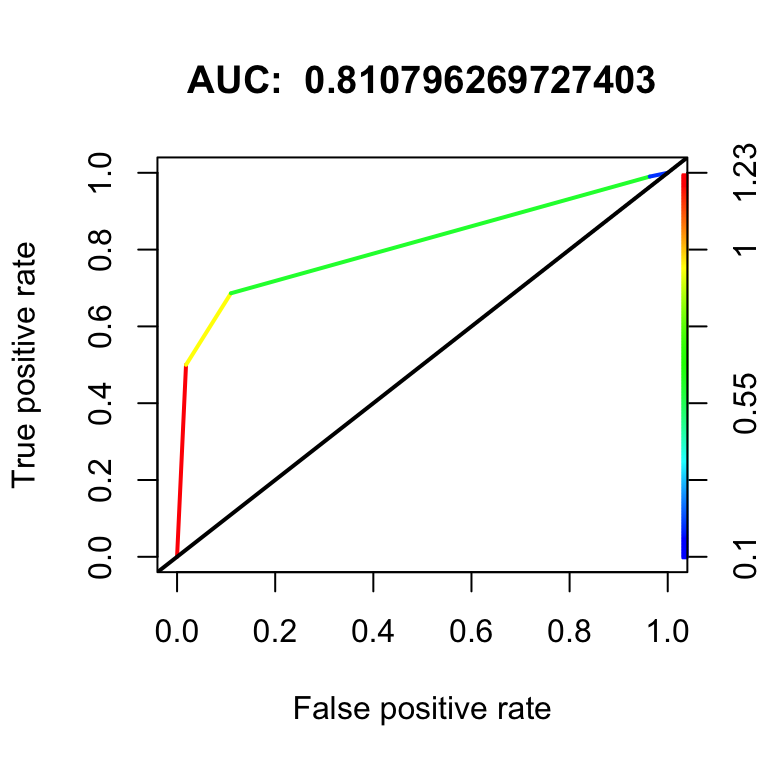

```r
plot(roc_perf, colorize=T, main=paste("AUC: ", roc_auc@y.values), lwd=2)
abline(a=0, b=1, lwd=2)
```

### Step 5 : Apply the model on test dataset

```r
# dt_model$coefnames
#"Pclass"    "Sexmale"   "Age"       "SibSp"     "Parch"     "Fare"      "EmbarkedQ" "EmbarkedS"
# Cabin is not used in the model, so don't do anything.

colSums(is.na(test_final))
```

```
## PassengerId      Pclass        Name         Sex         Age       SibSp
##           0           0           0           0          86           0
##       Parch      Ticket        Fare       Cabin    Embarked
##           0           0           1         327           0
```

```r
test_final$Age[is.na(test_final$Age)] <- median(test_final$Age, na.rm=TRUE)
test_final$Fare[is.na(test_final$Fare)] <- median(test_final$Fare, na.rm=TRUE)
colSums(is.na(test_final))
```

```
## PassengerId      Pclass        Name         Sex         Age       SibSp
##           0           0           0           0           0           0
##       Parch      Ticket        Fare       Cabin    Embarked
##           0           0           0         327           0
```

```r
pred_test <- predict(dt_model, newdata=test_final)
dim(test_final) # 418 11
```

```
## [1] 418  11
```

```r
length(pred_test) # 331
```

```
## [1] 418
```

```r
###???? why the output differs from data rows??? may be due to NA values


table(pred_test)
```

```
## pred_test
##   0   1
## 272 146
```

```r
submit_data <- data.frame(PassengerId = test_final$PassengerId, Survived = pred_test)
#write.csv(submit_data, file="output-DT-caret.csv", row.names=FALSE)

# make sure to check that there are no NA's
str(submit_data)
```

```
## 'data.frame':    418 obs. of  2 variables:
##  $ PassengerId: int  892 893 894 895 896 897 898 899 900 901 ...
##  $ Survived   : Factor w/ 2 levels "0","1": 1 2 1 1 2 1 2 1 2 1 ...
```

```r
print(summary(submit_data))
```

```
##   PassengerId     Survived
##  Min.   : 892.0   0:272
##  1st Qu.: 996.2   1:146
##  Median :1100.5
##  Mean   :1100.5
##  3rd Qu.:1204.8
##  Max.   :1309.0
```

```r
#Error in data.frame(PassengerId = test_raw$PassengerId, Survived = pred_test) :
#  arguments imply differing number of rows: 418, 331
```